# Fisheries and biodiversity intactness - GP projection

Compiled on Tue Jul 10 19:37:34 2018 by ohara

# 1 Setup

## 1.1 Match raster to Gall-Peters 10 km^2

Let’s adjust the fishing effort rasters to be fishing effort per year per km^2…

```r
### adjust JC's rasters to our (new) grid.  Only need to do this once!
rast_base <- raster(file.path(dir_git, 'spatial', 'cell_id_rast_gp.tif'))

# r1 <- raster(file.path(dir_data, 'gfw_data', 'monthly_mean_fishing_hours_casey.grd'))
f_hrs_rast <- raster(file.path(dir_data, 'gfw_data', 'total_fishing_hours_casey.grd'))
area_rast <- f_hrs_rast %>%
  setValues(values(raster::area(.)))

effort_reproj <- projectRaster(f_hrs_rast, rast_base, method = 'ngb')
writeRaster(effort_reproj, file.path(dir_data, 'gfw_data', 'fishing_effort_gp.tif'),
            overwrite = TRUE)

f_intensity <- f_hrs_rast / area_rast
f_intensity_reproj <- projectRaster(f_intensity, rast_base, method = 'ngb')
writeRaster(f_intensity_reproj, file.path(dir_data, 'gfw_data', 'fishing_intensity_gp.tif'),
            overwrite = TRUE)
```

```r
f_rast     <- raster(file.path(dir_data, 'gfw_data', 'fishing_effort_gp.tif'))
log_f_rast <- log10(f_rast)
```

Now let’s load the rasters of mean risk and associated variance, threatened spp, spp richness, and eez info. I’ll normalize threatend spp by dividing it by spp richness.

```r
cell_id_rast    <- raster(file.path(dir_git, 'spatial', 'cell_id_rast_gp.tif'))
eez_rast        <- raster(file.path(dir_git, 'spatial', 'eez_rast_gp.tif'))
mean_rr_rast    <- raster(file.path(dir_git, 'output', 'mean_rr_risk_raster_gp.tif'))
var_rr_rast     <- raster(file.path(dir_git, 'output', 'var_rr_risk_raster_gp.tif'))
n_spp_rast      <- raster(file.path(dir_git, 'output', 'n_spp_risk_raster_gp.tif'))
n_threat_rast   <- raster(file.path(dir_git, 'output', 'n_threat_raster_gp.tif'))
pct_threat_rast <- raster(file.path(dir_git, 'output', 'pct_threat_raster_gp.tif'))

### Gall-Peters doesn't have an EPSG?
gp_proj4 <- '+proj=cea +lon_0=0 +lat_ts=45 +x_0=0 +y_0=0 +ellps=WGS84 +units=m +no_defs'

land_poly <- sf::read_sf(file.path(dir_git, 'spatial', 'ne_10m_land', 'ne_10m_land.shp')) %>%
  st_transform(gp_proj4)
```

```r
# Get rasters into a data.frame
risk_f_df <- data.frame(cell_id      = values(cell_id_rast),
                        rgn_id       = values(eez_rast),
                        mean_rr_risk = values(mean_rr_rast),
                        var_rr_risk  = values(var_rr_rast),
                        n_spp        = values(n_spp_rast),
                        n_threat     = values(n_threat_rast),
                        pct_threat   = values(pct_threat_rast),
                        f_effort     = values(f_rast),
                        ln_f_effort  = values(log_f_rast)) %>%
  cbind(coordinates(mean_rr_rast)) %>%
  filter(!is.na(mean_rr_risk)) %>%
  left_join(read_csv(file.path(dir_git, 'spatial', 'rgn_names.csv')),
            by = c('rgn_id'))
```

# 2 Mean risk (range-rarity weighted)

## 2.1 Global

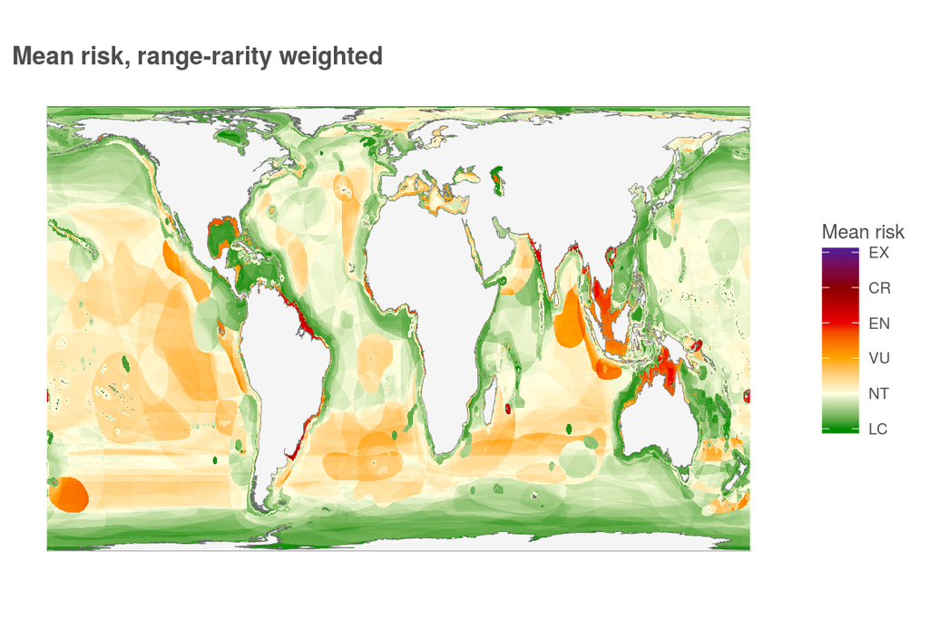

```r
ggplot() +
  geom_raster(data = risk_f_df, aes(x = x, y = y, fill = mean_rr_risk)) +
  scale_fill_gradientn(colors = c('green4', 'lightyellow', 'orange', 'red2', 'red4', 'purple4'),
                       limits = c(0, 1),
                       labels = c('LC', 'NT', 'VU', 'EN', 'CR', 'EX'),
                       breaks = c( 0.0,  0.2,  0.4,  0.6,  0.8,  1.0),
                       guide = guide_colorbar(frame.colour = "black",
                                              frame.linewidth = 1,
                                              ticks.colour = "black",
                                              ticks.linewidth = 1)) +
  geom_sf(data = land_poly, fill = 'grey96', color = 'grey40', size = .10) +
  coord_sf(datum = NA) +
  ggtheme_map() +
  labs(title = 'Mean risk, range-rarity weighted',
       fill  = 'Mean risk')
```

## 2.2 Regional

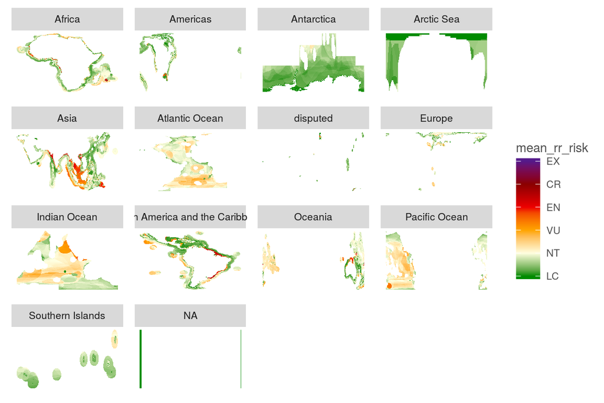

```r
ggplot() +
  geom_raster(data = risk_f_df, aes(x = x, y = y, fill = mean_rr_risk)) +
  scale_fill_gradientn(colors = c('green4', 'lightyellow', 'orange', 'red2', 'red4', 'purple4'),
                       limits = c(0, 1),
                       labels = c('LC', 'NT', 'VU', 'EN', 'CR', 'EX'),
                       breaks = c( 0.0,  0.2,  0.4,  0.6,  0.8,  1.0),
                       guide = guide_colorbar(frame.colour = "black",
                                              frame.linewidth = 1,
                                              ticks.colour = "black",
                                              ticks.linewidth = 1)) +
  ggtheme_map() +
  facet_wrap(~r1_label, scales = "free")
```

# 3 Mean risk (rr) vs fishing effort (log-transformed)

## 3.1 Global

```r
breaks <- c(0.01, 0.05, 0.1, 0.25, 0.33, 0.5, 0.66, 0.75, 0.9, 0.95, 0.99)

quantiles <- data.frame(f_effort     = quantile(risk_f_df$f_effort, breaks, na.rm = T),
                        ln_f_effort  = quantile(risk_f_df$ln_f_effort, breaks, na.rm = T),
                        mean_rr_risk = quantile(risk_f_df$mean_rr_risk, breaks, na.rm = T))
```

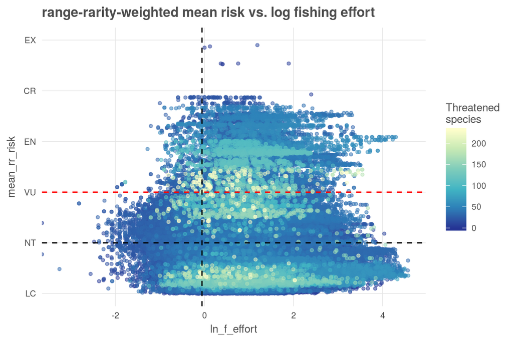

```r
risk_f_df %>%
  arrange(n_threat) %>%
  ggplot(aes(x = ln_f_effort, y = mean_rr_risk, color = n_threat)) +
  geom_point(size = 1, alpha = 0.5) +
  geom_vline(xintercept = quantiles$ln_f_effort[3], linetype = "dashed") +
  geom_hline(yintercept = c(0.2, 0.4), linetype = "dashed", color = c("black", "red")) +
  scale_color_distiller(palette = 'YlGnBu') +
  scale_y_continuous(labels = c('LC', 'NT', 'VU', 'EN', 'CR', 'EX'),
                     breaks = c( 0.0,  0.2,  0.4,  0.6,  0.8,  1.0)) +
  ggtheme_plot() +
  labs(title = 'range-rarity-weighted mean risk vs. log fishing effort',
       color = "Threatened\nspecies")
```

```r
# Threatened species
n_threat_spp_mean <- risk_f_df %>%
  filter(ln_f_effort < quantiles$ln_f_effort[3],
         mean_rr_risk < 0.2) %$%
  mean(n_threat) %>%
  formatC(digits = 2, format = "f")

n_threat_spp_sd <- risk_f_df %>%
  filter(ln_f_effort < quantiles$ln_f_effort[3],
         mean_rr_risk < 0.2) %$%
  sd(n_threat) %>%
  formatC(digits = 2, format = "f")

# Total species
n_spp_mean <- risk_f_df %>%
  filter(ln_f_effort < quantiles$ln_f_effort[3],
         mean_rr_risk < 0.2) %$%
  mean(n_spp) %>%
  formatC(digits = 2, format = "f")

n_spp_sd <- risk_f_df %>%
  filter(ln_f_effort < quantiles$ln_f_effort[3],
         mean_rr_risk < 0.2) %$%
  sd(n_spp) %>%
  formatC(digits = 2, format = "f")
```

## 3.2 Regional

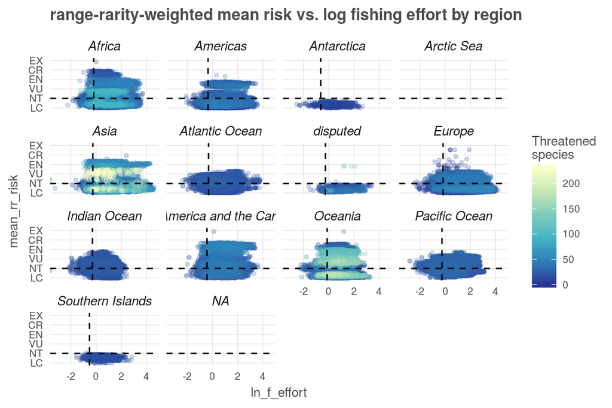

```r
quantiles_rgn <- risk_f_df %>%
  select(r1_label, f_effort, ln_f_effort, mean_rr_risk) %>%
  group_by(r1_label) %>%
  summarize_all(quantile, 0.05, na.rm = T) %>%
  ungroup()

risk_f_df %>%
  arrange(r1_label, n_threat) %>%
  ggplot(aes(x = ln_f_effort, y = mean_rr_risk, color = n_threat)) +
  geom_point(alpha = 0.2, size = 1) +
  geom_vline(data = quantiles_rgn, aes(xintercept = ln_f_effort), linetype = "dashed") +
  geom_hline(yintercept = 0.2, linetype = "dashed") +
  scale_color_distiller(palette = 'YlGnBu') +
  scale_y_continuous(labels = c('LC', 'NT', 'VU', 'EN', 'CR', 'EX'),
                     breaks = c( 0.0,  0.2,  0.4,  0.6,  0.8,  1.0)) +
  ggtheme_plot() +
  facet_wrap( ~ r1_label) +
  labs(title = 'range-rarity-weighted mean risk vs. log fishing effort by region',
       color = "Threatened\nspecies")
```

```r
risk_f_df %>%
  filter(ln_f_effort < quantiles$ln_f_effort[3],
         mean_rr_risk < 0.2) %>%
  group_by(r1_label) %>%
  summarize(n = n(),
            n_threat_mean = formatC(mean(n_threat), digits = 2, format = "f"),
            n_threat_sd = formatC(sd(n_threat), digits = 2, format = "f"),
            n_spp_mean = formatC(mean(n_spp), digits = 2, format = "f"),
            n_spp_sd = formatC(sd(n_spp), digits = 2, format = "f"),
            fi = sum(f_effort)) %>%
  ungroup() %>%
  mutate(spp = paste0(n_spp_mean, " (", n_spp_sd, ")"),
         threatened = paste0(n_threat_mean, " (", n_threat_sd, ")")) %>%
  select(r1_label, n, fi, spp, threatened) %>%
  knitr::kable(col.names = c("Region", "Number of cells", "Fishing hours", "Species", "Threatened spp"),
               caption = "Number of cells, average species richness, and average number of threatened species for pixels in the lower-left quadrat.")
```

Table 3.1: Number of cells, average species richness, and average number of threatened species for pixels in the lower-left quadrat.

| Region | Number of cells | Fishing hours | Species | Threatened spp |
| --- | --- | --- | --- | --- |
| Africa | 3508 | 1871.78722 | 84.19 (71.24) | 24.71 (9.74) |
| Americas | 2825 | 1444.36069 | 67.09 (35.24) | 18.70 (10.40) |
| Antarctica | 423 | 219.02208 | 32.41 (12.55) | 6.73 (4.26) |
| Asia | 1690 | 839.85000 | 152.87 (177.95) | 30.20 (22.34) |
| Atlantic Ocean | 8771 | 4809.09667 | 54.39 (6.02) | 19.70 (2.30) |
| disputed | 173 | 92.58069 | 103.15 (119.29) | 21.40 (14.49) |
| Europe | 3513 | 1928.26278 | 52.34 (30.22) | 14.65 (9.79) |
| Indian Ocean | 3185 | 1750.08139 | 55.99 (4.05) | 17.65 (1.55) |
| Latin America and the Caribbean | 1996 | 982.62292 | 78.16 (40.42) | 23.86 (6.03) |
| Oceania | 5484 | 2772.04458 | 117.95 (152.40) | 30.67 (18.95) |
| Pacific Ocean | 9159 | 4963.36625 | 60.39 (10.00) | 23.22 (3.49) |
| Southern Islands | 469 | 227.45708 | 54.43 (4.14) | 15.45 (2.02) |

```r
risk_f_df %>%
  filter(ln_f_effort < quantiles$ln_f_effort[3],
         mean_rr_risk > 0.4) %>%
  group_by(r1_label) %>%
  summarize(n = n(),
            n_threat_mean = formatC(mean(n_threat), digits = 2, format = "f"),
            n_threat_sd = formatC(sd(n_threat), digits = 2, format = "f"),
            n_spp_mean = formatC(mean(n_spp), digits = 2, format = "f"),
            n_spp_sd = formatC(sd(n_spp), digits = 2, format = "f"),
            fi = sum(f_effort)) %>%
  ungroup() %>%
  mutate(spp = paste0(n_spp_mean, " (", n_spp_sd, ")"),
         threatened = paste0(n_threat_mean, " (", n_threat_sd, ")")) %>%
  select(r1_label, n, fi, spp, threatened) %>%
  knitr::kable(col.names = c("Region", "Number of cells", "Fishing hours", "Species", "Threatened spp"),
               caption = "Number of cells, average species richness, and average number of threatened species for pixels in the upper-left quadrat.")
```

Table 3.2: Number of cells, average species richness, and average number of threatened species for pixels in the upper-left quadrat.

| Region | Number of cells | Fishing hours | Species | Threatened spp |
| --- | --- | --- | --- | --- |
| Africa | 107 | 52.99653 | 114.13 (52.29) | 33.02 (10.19) |
| Americas | 51 | 26.38389 | 177.39 (70.60) | 28.86 (7.33) |
| Asia | 135 | 66.16486 | 538.33 (367.63) | 106.62 (75.22) |
| Europe | 28 | 12.51375 | 55.82 (8.00) | 21.89 (11.01) |
| Indian Ocean | 288 | 168.83167 | 56.17 (1.93) | 21.11 (1.11) |
| Latin America and the Caribbean | 339 | 158.14819 | 106.47 (53.39) | 32.77 (8.35) |
| Oceania | 139 | 65.34458 | 456.58 (294.24) | 79.50 (40.20) |
| Pacific Ocean | 227 | 105.57236 | 65.09 (3.43) | 27.53 (1.71) |

# 4 Areas with low effort

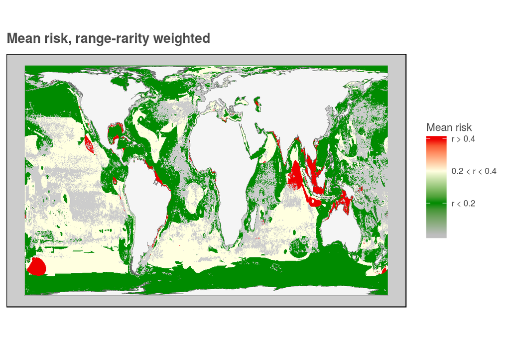

Figure 4.1: Mean risk, range-rarity weighted for regions with the bottom 10th percentile of fishing hours. Colors indicate whether the listes are located in the lower, middle, or upper quadrats outlined in the previous figure.

```r
risk_f_df %>%
  filter(ln_f_effort < quantiles$ln_f_effort[3] | is.na(ln_f_effort)) %>%
  mutate(mean_rr_risk_bin = case_when(mean_rr_risk > 0.4 ~ 3,
                                       mean_rr_risk < 0.2 ~ 1,
                                       TRUE ~ 2)) %>%
  ggplot() +
  geom_raster(aes(x = x, y = y, fill = mean_rr_risk_bin)) +
  scale_fill_gradientn(colors = c('gray', 'green4', 'lightyellow', 'red2'),
                       limits = c(0, 3),
                       labels = c("r < 0.2", "0.2 < r < 0.4", "r > 0.4"),
                       breaks = c(1, 2, 3),
                       guide = guide_colorbar(frame.colour = "black",
                                              frame.linewidth = 1,
                                              ticks.colour = "black",
                                              ticks.linewidth = 1)) +
  geom_sf(data = land_poly, fill = 'grey96', color = 'grey40', size = .10) +
  coord_sf(datum = NA) +
  ggtheme_map() +
  theme(panel.background = element_rect(fill = 'grey80')) +
  labs(title = 'Mean risk, range-rarity weighted',
       fill  = 'Mean risk')
```

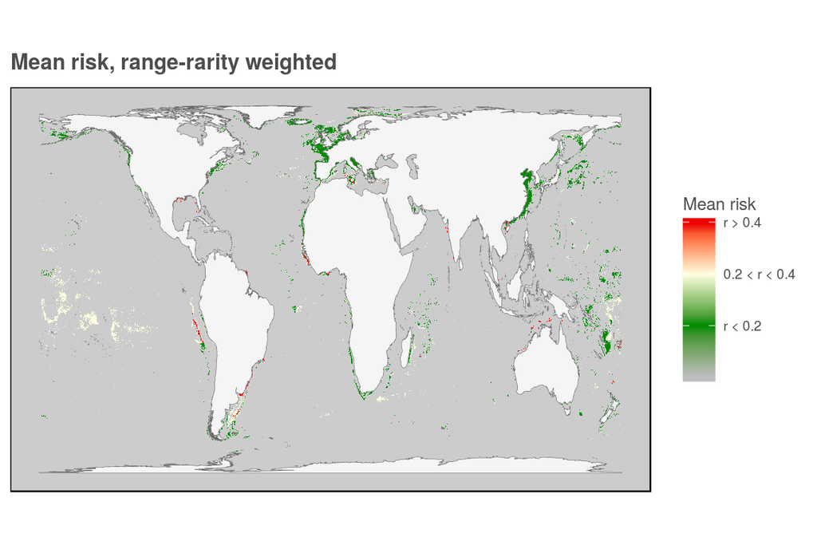

Figure 4.2: Mean risk, range-rarity weighted for regions with the top 10th percentile of fishing hours. Colors indicate whether the listes are located in the lower, middle, or upper quadrats outlined in the previous figure.

```r
risk_f_df %>%
  filter(ln_f_effort > quantiles$ln_f_effort[9]) %>%
  mutate(mean_rr_risk_bin = case_when(mean_rr_risk > 0.4 ~ 3,
                                       mean_rr_risk < 0.2 ~ 1,
                                       TRUE ~ 2)) %>%
  ggplot() +
  geom_raster(aes(x = x, y = y, fill = mean_rr_risk_bin)) +
  scale_fill_gradientn(colors = c('gray', 'green4', 'lightyellow', 'red2'),
                       limits = c(0, 3),
                       labels = c("r < 0.2", "0.2 < r < 0.4", "r > 0.4"),
                       breaks = c(1, 2, 3),
                       guide = guide_colorbar(frame.colour = "black",
                                              frame.linewidth = 1,
                                              ticks.colour = "black",
                                              ticks.linewidth = 1)) +
  geom_sf(data = land_poly, fill = 'grey96', color = 'grey40', size = .10) +
  coord_sf(datum = NA) +
  ggtheme_map() +
  theme(panel.background = element_rect(fill = 'grey80')) +
  labs(title = 'Mean risk, range-rarity weighted',
       fill  = 'Mean risk')
```

# 5 Short paragraph?

Great conservation benefits could be achieved at a low cost to fisheries (Fig 3.1). Conservation interventions may follow any of the two observed strategies of protecting nearly pristine sites or areas with higher impacts that could potentially be restored. The first approach would aim to implement marine protected areas in regions with low fishing effort (the bottom 10th percentile) and low mean risk (*i.e.* rrmr < 0.2). The average cell meeting these conditions contains 22.17 $\pm$ 11.11 threatened species and a total of 72.71 $\pm$ 76.77 species (M $\pm$ SD). Although highly variable across regions, this approach could protect sites where mean risk is low but have many threateend species (Table 3.1). Another strategy would be to protect areas where mean risk is high and fishing effort is low. The low fishing effort - high risk values of these areas could be caused by the presence of small-scale fisheries or where GFW data don’t have great ressolution (*e.g.* South China Sea), or by impacts that are not driven by fishing effort. On either case, limiting industrial fishing effort in these regions would produce similar benefits as the ones mentioned before (Table 3.2). A summary of the locations where fishing activity represents the lower 10th percentile is shown on Figure 4.1 and region-specific relationships of risk and fishing effort are presented in Figure 3.2.